# Vowel analysis using FastTrack

Takayuki Nagamine

2025-03-04

# 1 Introduction

FastTrack is a (nearly) automated formant tracking tool that enables you to extract the formant contours quickly and easily. The tool functions based on a number of praat scripts and as a plug-in in Praat, so there is no need for you to code anything. There is also room for customising the scripts to make more individualised tool. FastTrack is developed by Santiago Barreda at UC Davies and more information can be found here: https://github.com/santiagobarreda/FastTrack

Also, the following paper explains the tool in more detail:

[Barreda, S. (2021). Fast Track: fast (nearly) automatic formant-tracking using Praat. Linguistics Vanguard, 7(1), 20200051. https://doi.org/10.1515/lingvan-2020-0051](https://www.degruyter.com/document/doi/10.1515/lingvan-2020-0051/html)

## 1.1 Workflow overview

In the workshop, I will demonstrate my typical workflow of acoustic (spectral) analysis using FastTrack. I usually follow these steps:

1. **Record audio data** (well, quite obvious)
2. **Annotate audio files onto Praat Textgrid**
- I usually start this using forced alignment (e.g., Montreal Forced Aligner: MFA) and then refine segment boundaries manually.
- I use MFA because it can annotate segments using ARPABET that FastTrack can recognise.
- Helpful to create two tiers at least: word (orthography) and phone (ARPABET). You can manually annotate words first, and then MFA will create the phone tier for you.
3. **Define segments of interest**
- FastTrack starts to kick in here. By default, FastTrack looks for vowels as FastTrack is designed primarily for analysing vowels (or, to be more specific, vowel inherent spectral change: VISC). But the minimum requirement in using FastTrack is that formant structure is visible throughout each audio file to be analysed, and you can tweak the settings into analysing sonorant consonants (e.g., liquids, semi-vowels).
4. **Extract vowels (or vocalic portions of interest)**
- FastTrack estimates formants throughout each audio file. This means that it achieves the highest formant estimation accuracy when spectral structure is seen throughout each file.
- FastTrack has **Extract vowels** function that enables you to extract the vocalic portions of your interest before analysis.
5. **Estimate formants using Track Folder**
- Once individual segments have been extracted, you can bulk-estimate formant frequencies for all audio files stored in the same directory.
- Some parameters need to be specified, such as the maximum and minumum frequency of anlaysis windows, the number of formants to be extracted (3 or 4), the number of data points (i.e., `bins’) to be output etc.
- NB: The latest version of FastTrack seems to group sound files extracted from a single audio file into a folder.
6. **Visualise and run stats using R**
- This is the fun bit!

## 1.2 Workshop objectives

In this workshop, I will mainly explain and demonstrate steps 3-5 from above. If you would like to follow along, you can install FastTrack beforehand. A detailed step-by-step guide is available in [Santiago’s Github repository](https://github.com/santiagobarreda/FastTrack) with some video illustrations. See the wiki on his Github repository for the tutorial on installation (and many other things!)

## 1.3 Data

We are going to analyse vowel production from ``the North Wind and the Sun’’ passage produced by speakers of different L1 backgrounds. We will use the data from [the ALLSTAR Corpus](https://groups.linguistics.northwestern.edu/speech_comm_group/allsstar2/#!/). The ALLSTAR Corpus contains a number of spontaneous and scripted speech that were produced by English speakers from different language backgrounds:

Bradlow, A. R. (n.d.) ALLSSTAR: Archive of L1 and L2 Scripted and Spontaneous Transcripts And Recordings. Retrieved from https://oscaar3.ling.northwestern.edu/ALLSSTARcentral/#!/recordings.

You can download a subset of the corpus data to work with in this workshop from [here](https://github.com/TakayukiNagamine/fasttrack_soclab/blob/main/data.zip).

The data contains recordings of the North Wind and the Sun passage by 22 speakers from various L1 backgrounds: Chinese-Cantonese (n = 4), Chinese-Mandarin (n = 4), English (n = 4), Japanese (n = 2), Korean (n = 4), and Spanish (n = 4). In each language group, half the speakers are female and the other half male. The file name convention is: `ALL_[speaker number]_[gender: F or M]_[L1: CCT, CMN, ENG, JPN, KOR, SPA]_[L2: ENG]_NWS`. Each audio file is accompanied by an annotated TextGrid file, generated by Montreal Forced Aligner.

# 2 A brief note on installation

Santiago’s github page has a gentle tutorial on installation. You can select one of two ways to display FastTrack; compact and lazy formats.

The compact format creates an additional button just saying ``FastTrack’’ on your Praat object window, and you need to click the button to see further options. The lazy format displays all the options at once but this results in more buttons.

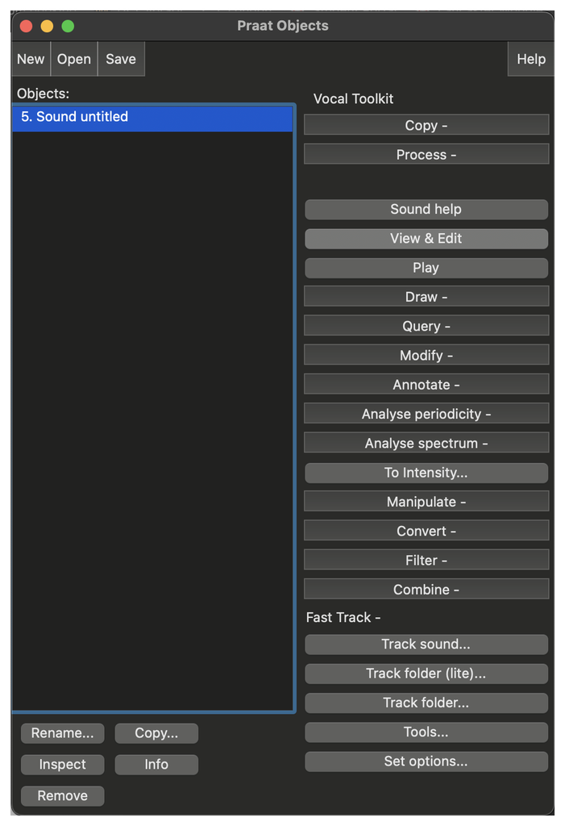

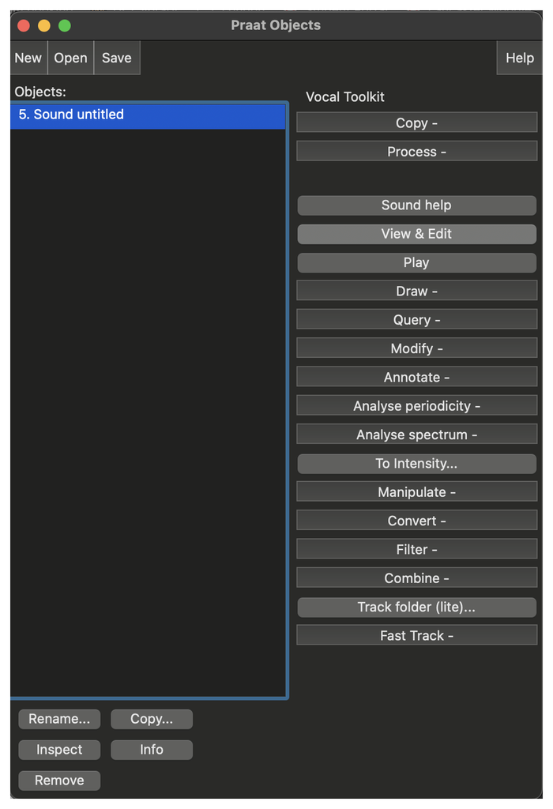

Lazy (left) and compact format (right)

# 3 Let’s begin the analysis!

## 3.1 Step 1: Extracting vowels

We have recorded speech data from participants and/or obtained corpus data already. After some agony, we have managed to segment everything and are now ready to proceed onto acoustic analysis.

When using FastTrack, the first thing we need to do is **to extract vocalic portions** that we would like to analyse. Let’s extract vowels using FastTrack before submitting them to formant estimation.

FastTrack extracts segments specified in the spreadsheet `vowelstoextract_default.csv`. By default, the csv file lists vowels, but you can modify the list if interested in extracted other types of sounds (e.g., liquids, semi-vowels). You can find this by going to: **FastTrack-master** -> **Fast Track** -> **dat**.

- When changing something here, I would strongly suggest that you keep the default file, too. FastTrack only recognises the spreadsheet when it’s named as `vowelstoextract_default.csv`, which means that you can just give a different name to the spreadsheets that you’d like to keep. For example, when I analysed liquids, I first copied the default file and renamed it into `vowelstoextract_vowel.csv`. I then modify the default file so that the list only contains /l/ and /r/.

### 3.1.1 Procedure

Here is a somewhat detailed workflow:

1. Download [**data.zip**](https://github.com/TakayukiNagamine/fasttrack_soclab/blob/main/data.zip) and save it somewhere on your computer.
2. FastTrack requires a certain repository structure, so let’s do this now. Specifically, we’ll need to save the audio and textgrid files in separate folder, named `sounds` and `textgrids` separately. Create new folders, give the appropriate names, and save the files in each folder.
- It might also be useful to create an `output` folder at this stage, too. This is where the extracted files, which we will use for formant estimation later on, will be spitted out.
- Directory structure is schematised below. Note the file name correspondence between sound and TextGrid files: they need to share the common names!

```
data
  |
  + - sounds
  |   |
  |   + - recording01.wav
  |   + - recording02.wav
  |   + - ...
  |
  + - textgrids
  |   |
  |   + - recording01.TextGrid
  |   + - recording02.TextGrid
  |   + - ...
  |
  + - output
```

3. Open **Praat** and throw a random file in the object window. This will trigger the FastTrack functions to appear in the menu section.
4. Select **Tools…**, then **Extract vowels with TextGrids**.
5. Once a window pops up, specify the following:
- **Sound folder**:
  - Path to ``sounds’’ in the data folder containing .wav files.
- **TextGrid folder**:
  - Path to ``textgrids’’ in the data folder containing .TextGrid files.
- **Output folder**:
  - Path to the folder where you wish to save the outputs. You could specify an existing location.
- **Which tier contains segmentation information?**:
  - Specify the tier in which phonemic transcription/segmentation has been performed. In the current example, the segmentation is done in Tier 2 so type 2.
- **Which tier contains word information?**:
  - Specify the tier with words. Type 1 in this case.
- **Is stress marked on vowels?**:
  - Tick the box if you wish to take stress into account. If you use MFA to segment the speech, stress is marked alongside each vowel. For example, you will find “AE1”, which means a TRAP vowel that bears the primary stress, or “AE2” the secondary stress, etc.
6. **Press OK** and excute!

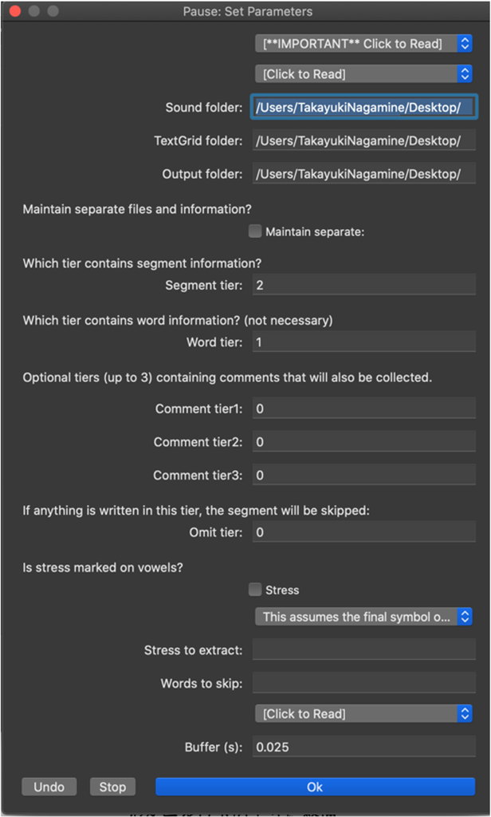

Vowel extraction setting window

### 3.1.2 Output files

Let’s check what files have been created at this stage. Go to the `output` folder to check what it contains:

- **segmentation_information.csv**: A detailed summary of the extraction process, including input and output (audio) files, labels, duration, previous and next adjacent segments and stress information.
- **file_information.csv**: A brief summary of the correspondence between output files, labels and colours. Colours are relevant when visualising vowels using Praat.
- **sounds**: Extracted audio files. You’ll notice that the file names now have some numbers added to the end (e.g., ALL_005_M_CMN_ENG_NWS_**0002**.wav), indicating the order of extraction from the original audio file.

## 3.2 Step 2: Tracking a folder

Having extracted vowels (or any vocalic segments), we’re now ready to move onto the fun bit: formant tracking! Here is what FastTrack does:

- FastTrack does a lot of regressions and chooses the best analysis out of multiple candidates automatically. It can also return images of all candidates and the winners for visual inspection.
- It estimates the formant frequencies at the multiple time points throughout the vowel duration.
- The output is a csv file summarising the analysis, which can then be imported into R for tidy up, visualisation, statistics, etc.

### 3.2.1 Procedure

You should now see multiple folders in your `output` folder (schematised below). Each contains sound files extracted from a `source’ audio file. We will run formant tracking folder by folder.

NB: Former versions of FastTrack saves all extracted sound files into one place, allowing us to track formants in all sound files at once. If you prefer, you might want to look at [this page](https://github.com/santiagobarreda/FastTrack/commit/6bf6a0742c1d069e86d361fc99dd8afbd97823d8?diff=unified&w=0).

```
data
  |
  + - sounds
  |   |
  |   + - recording01.wav
  |   + - recording02.wav
  |   + - ...
  |
  + - textgrids
  |   |
  |   + - recording01.TextGrid
  |   + - recording02.TextGrid
  |   + - ...
  |
  + - output
      |
      + - recording01
      |   |
      |   + - file_information.csv
      |   + - segmentation_info.csv
      |   + - sounds
      |    |
      |    + - recording01_0001.wav
      |    + - recording01_0002.wav
      |    + - recording01_0003.wav
      |    + - ...
      |
      + - recording02
          |
          + - ...
```

1. Make sure that you know where the `output` folder is and that you see sub-folders containing at least: (1) file_information.csv, (2) segment_information.csv, and (3) a sounds folder containing a bunch of segmented audio files.
2. Open **Praat** and throw a random file in the object window. This will trigger the FastTrack functions to appear in the menu section (if FastTrack is installed properly).
3. Select **Track folder…**.
4. Specify the path to **each folder in the output folder** in the ``Folder’’ section. (Hint: this is not the path to the **sounds** folder!)
5. Adjust parameters for your needs. This includes:
- **Lowest/highest analysis frequency**: The range of upper limit of the frequency window that FastTrack seeks formants. FastTrack alters the ceiling of the analysis window in a number of steps to identify the most optimal formant estimation.
  - **Note:** It is recommended that we do formant tracking for female and male speakers separately due to anatomical differences such as vocal tract length (details [here](https://github.com/santiagobarreda/FastTrack/wiki/getting-a-good-analysis)). Given this, we will conduct analysis for female speakers with the 5000-7000 Hz range and for male speakers 4500-6500 Hz range.
- **Number of steps**: Basically the number of iteration of the upper limit adjustment. 24 here means that FastTrack adjusts the upper frequency limit in 24 steps from the lowest to highest analysis frequency that you have specified in the previous step.
- **Number of formants**: Obviously how many formants you’d like to extract. This has an impact of the formant estimation accuracy, so explore a little if you don’t get a satisfactory analysis.
- **Make images comparing analysis/showing winners**: You can choose whether you’d like to have an .png file for each analysis and each winner. I’d always tick the boxes here, but this depends on how much storage you have.
- Also, do not forget to tick **Show Progress**: otherwise it’d look like the computer is frozen and it wouldn’t let you know how much time it takes to process everything.
6. Hit **OK** and run it!

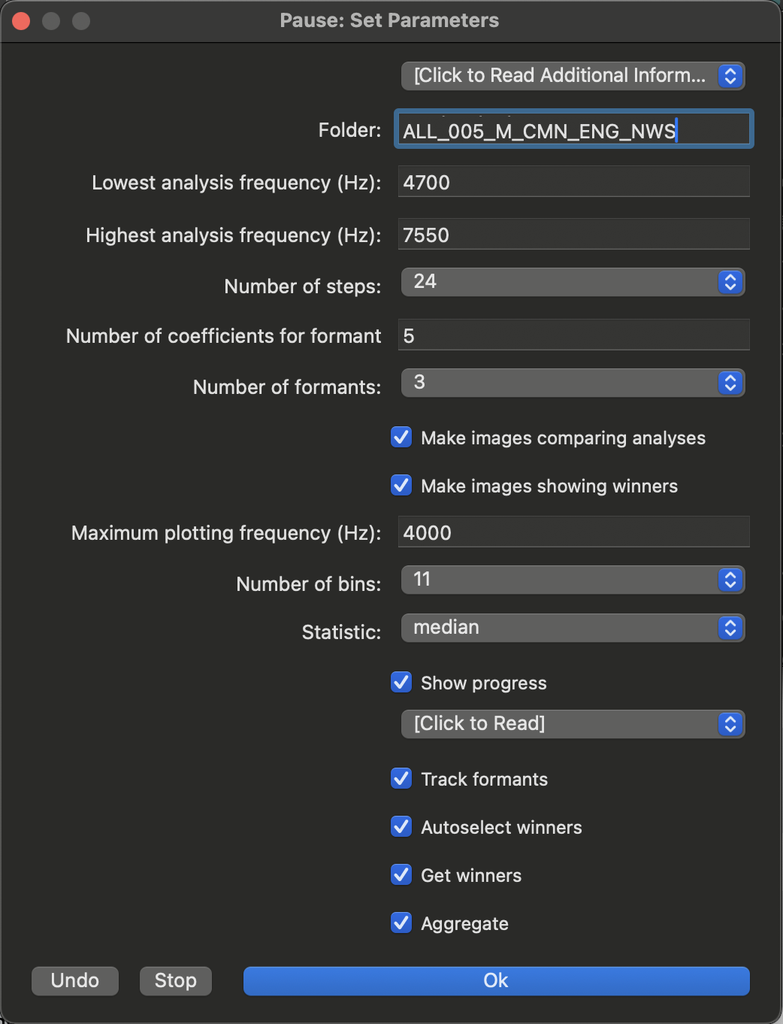

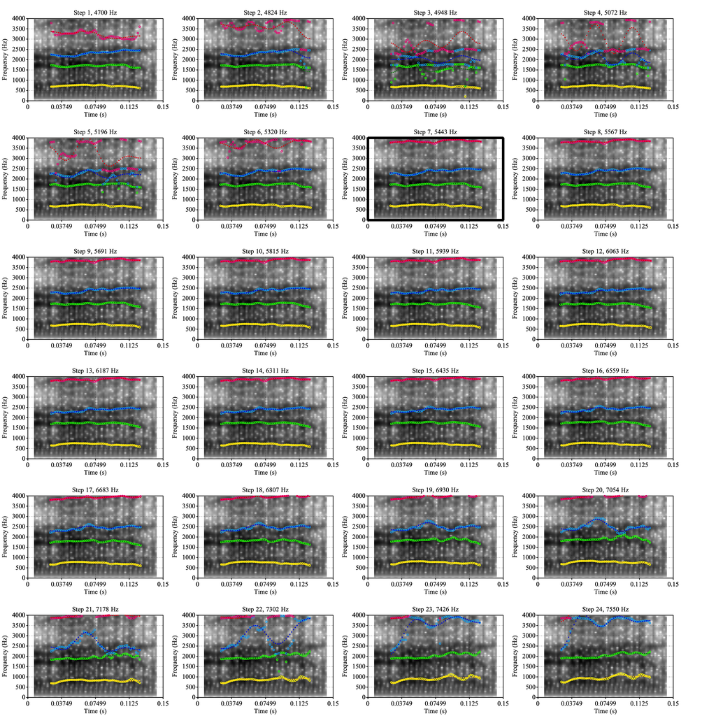

Setting window for formant estimation (left) and an example of comparison image (right)

### 3.2.2 Output files

In each of subdirectories in the ``output’’ folder, you’ll get quite a few output files from this stage. Let’s take a look at some of them that are most relevant here:

- **aggregated_data.csv**: A spreadsheet summarising (1) input file, (2) duration, (3) formant measurement averaged into the pre-specified number of bins (e.g., 11) for each vowel analysed here. This can be found in the **processed_data** folder. (See the image below for a quick overview.)
- **winners.csv**: A spreadsheet summarising which analysis step yields the most accurate formant tracking based on regression. Useful when you are not satisfied with the winner auto-selected by FastTrack and identify another analysis to be better.
- **images_comparison**: A folder showing the results of the step-wise formant estimation. Useful when evaluating formant tracking quality relative to each of the analysis steps.
- **images_winner**: A folder containing images for each `winning’ analysis for each sound file.
- **csvs**: A folder containing initial formant tracking sampled at 2ms interval (before FastTrack bins them into a smaller number of data points) for each winning analysis. Useful for a finer-grained analysis.

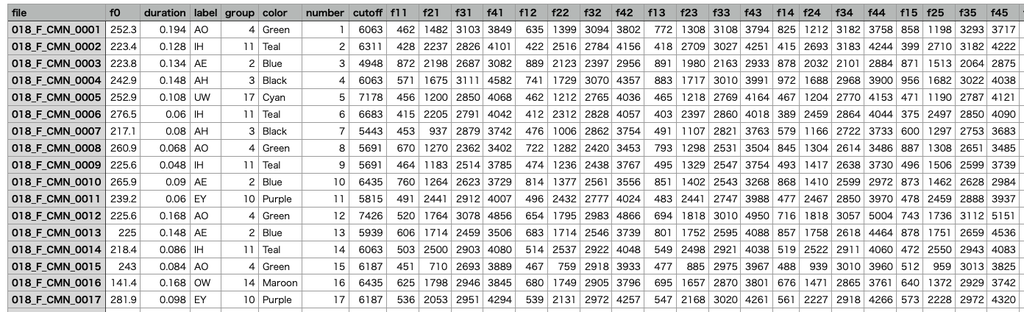

An example of Aggregate_data.csv

# 4 Data processing 1: `aggregated_data.csv`

Acoustic analysis is done, hooray! Now let’s move onto the more fun part – data wrangling, visualiastion and analysis using R. I can think of two broad paths to data analysis, and I’ll explain them one by one below.

An easier way of data analysis is to use `aggregated_data.csv`. Here, let’s convert the file format in a more tidyverse-friendly manner and then try some plotting.

Data transformation here is based on the codes originally written by Dr Sam Kirkham (Lancaster University). We will first import relevant data sets: aggregated_data.csv and segmentation_info.csv.

## 4.1 Extracting aggregated_data.csv

```r
# Set the main directory
main_dir <- getwd()
## The working directory of an R Markdown document is defined as where it's saved, and we'll use this as a main directory.

# Get all subdirectories
subdirs <- list.dirs(paste0(main_dir, "/data/output"), recursive = TRUE)
## This line looks through all subdirectories in a path -- in this case, we'd like to look through all subdirectories in the 'output' folder, which is stored in the 'data' folder found in the main directory. paste0(...) specifies this.

# Initialize an empty data frame
aggregated_data <- data.frame()

# Loop through subdirectories
for (subdir in subdirs) {
  # Define the file path
  file_path <- file.path(paste0(subdir, "/processed_data"), "aggregated_data.csv")

  # Check if the file exists
  if (file.exists(file_path)) {
    # Read the CSV file
    temp_data <- read.csv(file_path, stringsAsFactors = FALSE)

    # append to the final data frame
    aggregated_data <- bind_rows(aggregated_data, temp_data)
  }
}

# Check file
head(aggregated_data)
```

```
##                         file    f0 duration label group color number cutoff f11
## 1 ALL_005_M_CMN_ENG_NWS_0001 126.7    0.030    AH     3 Black      1   4935 210
## 2 ALL_005_M_CMN_ENG_NWS_0002 201.7    0.148    AO     4 Green      2   4848 566
## 3 ALL_005_M_CMN_ENG_NWS_0003 167.7    0.150    IH    11  Teal      3   5717 350
## 4 ALL_005_M_CMN_ENG_NWS_0004 159.6    0.290    AE     2  Blue      4   4848 536
## 5 ALL_005_M_CMN_ENG_NWS_0005 141.4    0.130    AH     3 Black      5   4500 332
## 6 ALL_005_M_CMN_ENG_NWS_0006 151.9    0.188    AH     3 Black      6   5978 376
##    f21  f31 f12  f22  f32 f13  f23  f33 f14  f24  f34 f15  f25  f35 f16  f26
## 1 1378 2525 207 1381 2529 207 1392 2525 206 1404 2522 202 1392 2522 198 1361
## 2 1448 2758 598 1402 2708 594 1323 2647 637 1170 2739 685 1141 2701 616 1051
## 3 1340 2411 394 1401 2444 426 1531 2478 444 1604 2502 450 1636 2565 446 1698
## 4 1713 2790 553 1756 2775 573 1723 2825 589 1747 2781 599 1780 2620 603 1744
## 5 1436 2688 383 1441 2632 434 1437 2614 447 1440 2606 443 1435 2591 423 1463
## 6 1589 2660 469 1587 2679 502 1623 2656 555 1619 2681 560 1596 2682 553 1569
##    f36 f17  f27  f37 f18  f28  f38 f19  f29  f39 f110 f210 f310 f111 f211 f311
## 1 2520 194 1349 2533 194 1375 2560 197 1409 2582  200 1427 2586  198 1443 2577
## 2 2725 600 1061 2789 612 1067 2863 614 1069 2849  601 1044 2911  544 1016 2873
## 3 2606 434 1667 2695 427 1663 2719 410 1695 2747  387 1690 2771  348 1670 2834
## 4 2669 605 1740 2630 623 1662 2662 607 1589 2629  582 1540 2622  580 1516 2763
## 5 2589 411 1476 2664 311 1508 2656 905 1759 2673 1663 2104 2720 1562 2236 2938
## 6 2725 542 1480 2782 502 1442 2887 430 1273 2992  395 1189 3085  417 1109 3222
```

## 4.2 Extracting segmentation info

```r
# Set the main directory
main_dir <- getwd()
## The working directory of an R Markdown document is defined as where it's saved, and we'll use this as a main directory.

# Get all subdirectories
subdirs <- list.dirs(paste0(main_dir, "/data/output"), recursive = TRUE)
## This line looks through all subdirectories in a path -- in this case, we'd like to look through all subdirectories in the 'output' folder, which is stored in the 'data' folder found in the main directory. paste0(...) specifies this.

# Initialize an empty data frame
segmentation_info <- data.frame()

# Loop through subdirectories
for (subdir in subdirs) {
  # Define the file path
  file_path <- file.path(subdir, "segmentation_info.csv")

  # Check if the file exists
  if (file.exists(file_path)) {
    # Read the CSV file
    temp_data <- read.csv(file_path, stringsAsFactors = FALSE)

    # append to the final data frame
    segmentation_info <- bind_rows(segmentation_info, temp_data)
  }
}

# Check file
head(segmentation_info)
```

```
##               inputfile                 outputfile vowel interval duration
## 1 ALL_005_M_CMN_ENG_NWS ALL_005_M_CMN_ENG_NWS_0001    AH        3     0.03
## 2 ALL_005_M_CMN_ENG_NWS ALL_005_M_CMN_ENG_NWS_0002    AO        5     0.15
## 3 ALL_005_M_CMN_ENG_NWS ALL_005_M_CMN_ENG_NWS_0003    IH        9     0.15
## 4 ALL_005_M_CMN_ENG_NWS ALL_005_M_CMN_ENG_NWS_0004    AE       12     0.29
## 5 ALL_005_M_CMN_ENG_NWS ALL_005_M_CMN_ENG_NWS_0005    AH       16     0.13
## 6 ALL_005_M_CMN_ENG_NWS ALL_005_M_CMN_ENG_NWS_0006    AH       18     0.19
##   start  end previous_sound next_sound omit stress  word word_interval
## 1  0.24 0.27             DH          N    0      0   the             2
## 2  0.34 0.49              N          R    0      1 north             3
## 3  0.76 0.91              W          N    0      1  wind             4
## 4  1.13 1.42              D          N    0      1   and             5
## 5  1.61 1.74             DH          S    0      0   the             6
## 6  1.84 2.03              S          N    0      1   sun             7
##   word_start word_end previous_word next_word
## 1       0.20     0.27             -     north
## 2       0.27     0.63           the      wind
## 3       0.63     1.13         north       and
## 4       1.13     1.56          wind       the
## 5       1.56     1.74           and       sun
## 6       1.74     2.06           the      were
```

## 4.3 Binding `aggregated_data.csv` and `segmentation_info.csv`

```r
## Rename the "outputfile" column to "file" so that it is compatible with the "aggregated_data.csv".
segmentation_info <- segmentation_info |>
  dplyr::rename(file = outputfile)

## Merging the two csv files by the "outputfile" column
df <- dplyr::full_join(aggregated_data, segmentation_info, by = "file")

## Duration column is duplicated so drop one
df <- df |>
  dplyr::select(-duration.y) |>
  dplyr::rename(
    duration = duration.x
  )

## Omit NA -- FastTrack omits tokens shorter than 30ms
df <- na.omit(df)

## Check data
head(df)
```

```
##                         file    f0 duration label group color number cutoff f11
## 1 ALL_005_M_CMN_ENG_NWS_0001 126.7    0.030    AH     3 Black      1   4935 210
## 2 ALL_005_M_CMN_ENG_NWS_0002 201.7    0.148    AO     4 Green      2   4848 566
## 3 ALL_005_M_CMN_ENG_NWS_0003 167.7    0.150    IH    11  Teal      3   5717 350
## 4 ALL_005_M_CMN_ENG_NWS_0004 159.6    0.290    AE     2  Blue      4   4848 536
## 5 ALL_005_M_CMN_ENG_NWS_0005 141.4    0.130    AH     3 Black      5   4500 332
## 6 ALL_005_M_CMN_ENG_NWS_0006 151.9    0.188    AH     3 Black      6   5978 376
##    f21  f31 f12  f22  f32 f13  f23  f33 f14  f24  f34 f15  f25  f35 f16  f26
## 1 1378 2525 207 1381 2529 207 1392 2525 206 1404 2522 202 1392 2522 198 1361
## 2 1448 2758 598 1402 2708 594 1323 2647 637 1170 2739 685 1141 2701 616 1051
## 3 1340 2411 394 1401 2444 426 1531 2478 444 1604 2502 450 1636 2565 446 1698
## 4 1713 2790 553 1756 2775 573 1723 2825 589 1747 2781 599 1780 2620 603 1744
## 5 1436 2688 383 1441 2632 434 1437 2614 447 1440 2606 443 1435 2591 423 1463
## 6 1589 2660 469 1587 2679 502 1623 2656 555 1619 2681 560 1596 2682 553 1569
##    f36 f17  f27  f37 f18  f28  f38 f19  f29  f39 f110 f210 f310 f111 f211 f311
```

[output cut: 20 more lines]

## 4.4 Converting data frame into a long data

Let’s convert the data frame into long format for a better handling with tidyverse.

```r
df_long <- df |>
  tidyr::pivot_longer(contains(c("f1", "f2", "f3")), # add "f4" if you extract F4 as well
               names_to = c("formant", "timepoint"),
               names_pattern = "(f\\d)(\\d+)",
               values_to = "hz")
```

Then, we will add proportional time information here – we have extracted the formant frequencies that have been binned into 11 points, meaning that we can express the temporal information from 0% to 100% with a 10% increment.

If you recall, the audio file names contain information about the speaker background (e.g., `ALL_005_M_CMN_ENG_NWS`). Let’s add them into the data frame, too.

```r
df_long <- df_long |>
  tidyr::spread(key = formant, value = hz) |>
  dplyr::mutate(
    timepoint = as.numeric(timepoint),
    percent = (timepoint - 1) * 10, # adding proportional time
    speaker =
      str_sub(file, start = 5, end = 7), # speaker ID: three digits
    speaker = as.factor(speaker),
    gender =
      str_sub(file, start = 9, end = 9), # gender: F or M
    L1 =
      str_sub(file, start = 11, end = 13), # L1: CMN, CCT ...
  )

# within-speaker normalisation
df_long <- df_long |>
  dplyr::group_by(speaker) |>
  dplyr::mutate(
    f1z = scale(f1),
    f2z = scale(f2),
    f3z = scale(f3)
  ) |>
  dplyr::ungroup()

# check data
df_long |>
  dplyr::group_by(gender, L1) |>
  dplyr::summarise() |>
  dplyr::ungroup()
```

```
## # A tibble: 12 × 2
##    gender L1
##    <chr>  <chr>
##  1 F      CCT
##  2 F      CMN
##  3 F      ENG
##  4 F      JPN
##  5 F      KOR
##  6 F      SPA
##  7 M      CCT
##  8 M      CMN
##  9 M      ENG
## 10 M      JPN
## 11 M      KOR
## 12 M      SPA
```

The data looks good! On we go to visualisation!

## 4.5 Data visualisation

Let’s try some data visualisation. Having temporal information in a proportional manner is useful because you can extract formant frequencies at an arbitrary point in time during each vowel interval.

Let’s first try visualising monophthongs based on midpoint measurement. We don’t filter anything here as it’d be interesting to see some variability in the data. But as seen in the commented out portion, you could filter tokens out based on e.g., surrounding segments.

```r
df_long_mono <- df_long |>
  dplyr::filter(
    # !next_sound %in% c("R", "W", "Y"), # monophthongs followed by /r/, /w/, and /j/ were avoided
    # !previous_sound %in% c("R", "W", "Y"), # monophthongs preceded by /r/, /w/, and /j/ were avoided
    # !next_sound %in% c("L", "NG"), # monophthongs followed by /l/ and /ng/ were avoided
    percent == 50, # specifying vowel midpoint
    !(vowel %in% c("AW", "AY", "EY", "OW", "OY")) # monophthongs
  ) |>
  dplyr::mutate(
    vowel_ipa =
      case_when(
        str_detect(vowel, "AA") ~ "ɑ",
        str_detect(vowel, "AE") ~ "æ",
        str_detect(vowel, "AH") ~ "ʌ",
        str_detect(vowel, "AO") ~ "ɔ",
        str_detect(vowel, "EH") ~ "ɛ",
        str_detect(vowel, "ER") ~ "ɝ",
        str_detect(vowel, "IH") ~ "ɪ",
        str_detect(vowel, "IY") ~ "i",
        str_detect(vowel, "UH") ~ "ʊ",
        str_detect(vowel, "UW") ~ "u",
        )
    ) # add IPA symbols for visualisation
```

We need mean formant values where we’ll put the IPA labels.

```r
# Calculate vowel means
df_mean <- df_long_mono |>
  dplyr::group_by(gender, L1, vowel, vowel_ipa) |>
  dplyr::summarise(
    m_f1 = mean(f1z),
    m_f2 = mean(f2z)
  ) |>
  dplyr::ungroup() |>
  dplyr::mutate(
    L1 = case_when(
      L1 == "CCT" ~ "Cantonese",
      L1 == "CMN" ~ "Mandarin",
      L1 == "ENG" ~ "English",
      L1 == "KOR" ~ "Korean",
      L1 == "JPN" ~ "Japanese",
      L1 == "SPA" ~ "Spanish",
    ) # making L1 labels to be more readable
  )
```

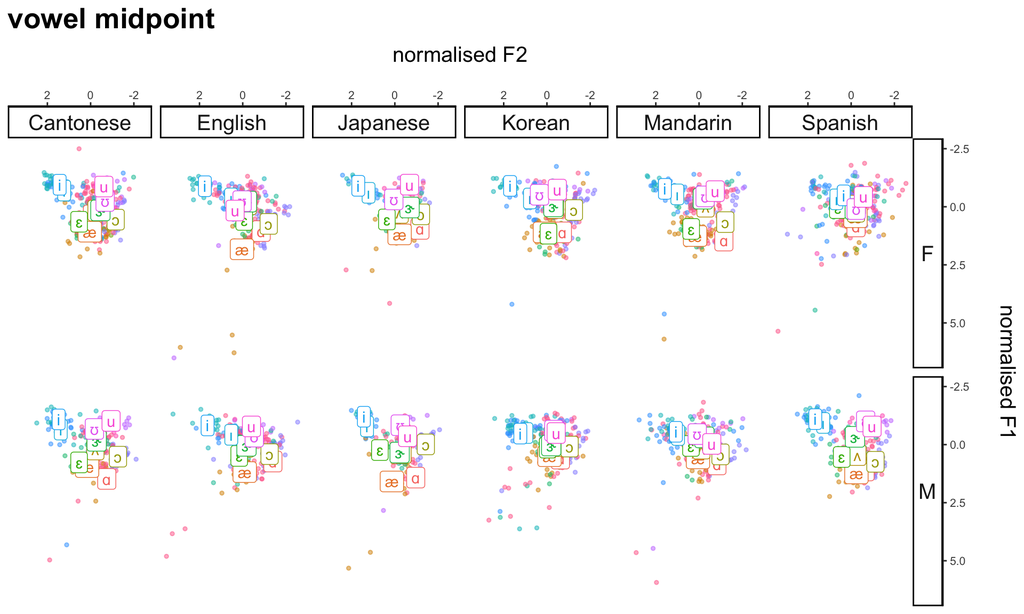

```r
# plot
df_long_mono |>
  dplyr::mutate(
    L1 = case_when(
      L1 == "CCT" ~ "Cantonese",
      L1 == "CMN" ~ "Mandarin",
      L1 == "ENG" ~ "English",
      L1 == "KOR" ~ "Korean",
      L1 == "JPN" ~ "Japanese",
      L1 == "SPA" ~ "Spanish",
    ) # making L1 labels to be more readable
  ) |>
  ggplot(aes(x = f2z, y = f1z, colour = vowel_ipa)) +
  geom_point(size = 1, alpha = 0.5, show.legend = FALSE) +
  geom_label(data = df_mean, aes(x = m_f2, y = m_f1, label = vowel_ipa, colour = vowel), show.legend = FALSE) +
  scale_x_reverse(position = "top") +
  scale_y_reverse(position = "right") +
  labs(x = "normalised F2\n", y = "normalised F1\n", title = "vowel midpoint") +
  facet_grid(gender ~ L1) +
  theme(axis.text = element_text(size = 8),
        axis.title = element_text(size = 15),
        strip.text.x = element_text(size = 15),
        strip.text.y = element_text(size = 15, angle = 0),
        plot.title = element_text(size = 20, hjust = 0, face = "bold")
  )
```

We can also plot temporal changes in formant frequency. For example, here is a comparison of F2 dynamics between L1 English and L1 Japanese speakers. Please feel free to explore any other L1 comparisons!

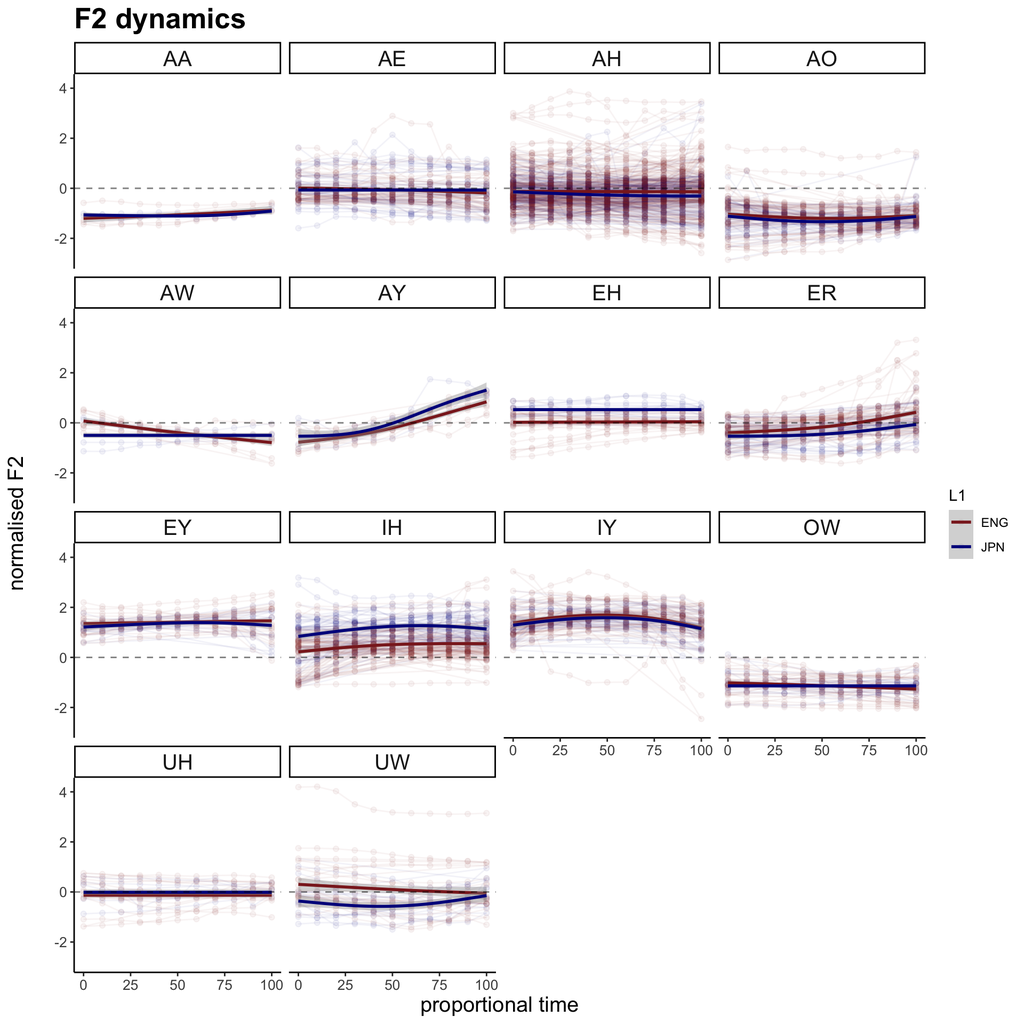

```r
df_long |>
  dplyr::filter(
    L1 %in% c("ENG", "JPN") # change for different L1 pairs
  ) |>
  ggplot(aes(x = percent, y = f2z, colour = L1)) +
  geom_point(alpha = 0.05) +
  geom_path(aes(group = number), alpha = 0.05) +
  geom_smooth(aes(group = L1)) + # you could also add smooths
  geom_hline(yintercept = 0, linetype = "dashed", alpha = 0.5) +
  labs(x = "proportional time", y = "normalised F2\n", title = "F2 dynamics") +
  facet_wrap( ~ vowel) +
  scale_colour_manual(values = alpha(c("brown4", "blue4"))) +
  theme(axis.text = element_text(size = 10),
        axis.title = element_text(size = 15),
        strip.text.x = element_text(size = 15),
        strip.text.y = element_text(size = 15, angle = 0),
        plot.title = element_text(size = 20, hjust = 0, face = "bold")
  )
```

## 4.6 Data analysis

Finally, we could try fitting some statistical models to investigate whether vowel realisations differ depending on the speaker’s L1 background.

We could fit ordinary linear-mixed effect models for the midpoint measurement.

```r
library(lme4)
library(lmerTest)
library(emmeans)

# converting variables into factor and dropping empty levels
df_long_mono$vowel <- droplevels(as.factor(df_long_mono$vowel))
df_long_mono$vowel <- as.factor(df_long_mono$vowel)
df_long_mono$speaker <- as.factor(df_long_mono$speaker)
df_long_mono$L1 <- as.factor(df_long_mono$L1)

# run model
m1 <- lme4::lmer(f2z ~ L1 + vowel + L1:vowel + (1|word), data = df_long_mono, REML = FALSE)

## model summary
summary(m1)
```

```
## Linear mixed model fit by maximum likelihood  ['lmerMod']
## Formula: f2z ~ L1 + vowel + L1:vowel + (1 | word)
##    Data: df_long_mono
##
##      AIC      BIC   logLik deviance df.resid
##   5289.2   5655.4  -2582.6   5165.2     2653
##
## Scaled residuals:
##     Min      1Q  Median      3Q     Max
## -5.0715 -0.5016  0.0021  0.4648  5.9955
##
## Random effects:
##  Groups   Name        Variance Std.Dev.
##  word     (Intercept) 0.1427   0.3778
##  Residual             0.3713   0.6093
## Number of obs: 2715, groups:  word, 55
##
## Fixed effects:
##               Estimate Std. Error t value
## (Intercept)    0.04024    0.35676   0.113
## L1CMN         -0.57142    0.41271  -1.385
## L1ENG         -0.70622    0.41271  -1.711
## L1JPN         -0.64669    0.51299  -1.261
## L1KOR         -0.25043    0.41271  -0.607
## L1SPA         -0.06057    0.37092  -0.163
## vowelAE       -0.05163    0.36848  -0.140
## vowelAH       -0.32671    0.35979  -0.908
## vowelAO       -1.01023    0.36698  -2.753
## vowelEH        0.21684    0.39135   0.554
## vowelER       -0.12947    0.36981  -0.350
## vowelIH        0.92521    0.36890   2.508
## vowelIY        1.19574    0.37074   3.225
## vowelUH       -0.46279    0.45364  -1.020
## vowelUW       -0.68425    0.39372  -1.738
## L1CMN:vowelAE  0.61313    0.42881   1.430
## L1ENG:vowelAE  0.67782    0.43214   1.569
## L1JPN:vowelAE  0.49237    0.53111   0.927
## L1KOR:vowelAE  0.15033    0.42822   0.351
## L1SPA:vowelAE -0.20931    0.38911  -0.538
## L1CMN:vowelAH  0.60828    0.41822   1.454
```

[output cut: 24 more lines]

```
## L1CMN:vowelIY  0.46481    0.43268   1.074
## L1ENG:vowelIY  0.94183    0.43189   2.181
## L1JPN:vowelIY  0.75639    0.53581   1.412
## L1KOR:vowelIY  0.26658    0.43189   0.617
## L1SPA:vowelIY -0.43927    0.39178  -1.121
## L1CMN:vowelUH  0.89684    0.48188   1.861
## L1ENG:vowelUH  0.87789    0.48188   1.822
## L1JPN:vowelUH  1.06491    0.60728   1.754
## L1KOR:vowelUH  0.77383    0.48837   1.585
## L1SPA:vowelUH  0.03145    0.44662   0.070
## L1CMN:vowelUW  0.66303    0.45099   1.470
## L1ENG:vowelUW  1.56509    0.45491   3.440
## L1JPN:vowelUW  0.84742    0.56332   1.504
## L1KOR:vowelUW  0.60538    0.45268   1.337
## L1SPA:vowelUW  0.07059    0.41493   0.170
```

```r
# significance testing
## nested model for the interaction
m2 <- lme4::lmer(f2z ~ L1 + vowel + (1|word), data = df_long_mono, REML = FALSE)

## model comparison: full model significantly improves the model fit
anova(m1, m2, test = "Chisq")
```

```
## Data: df_long_mono
## Models:
## m2: f2z ~ L1 + vowel + (1 | word)
## m1: f2z ~ L1 + vowel + L1:vowel + (1 | word)
##    npar    AIC    BIC  logLik deviance  Chisq Df Pr(>Chisq)
## m2   17 5404.3 5504.7 -2685.2   5370.3
## m1   62 5289.2 5655.4 -2582.6   5165.2 205.12 45  < 2.2e-16 ***
## ---
## Signif. codes:  0 '***' 0.001 '**' 0.01 '*' 0.05 '.' 0.1 ' ' 1
```

We could also do a post-hoc analysis using `emmeans`, although this results in a massive comparison…

```r
## post-hoc anlaysis
emmeans::emmeans(m1, pairwise ~ L1 | vowel)
```

[output not shown]

# 5 Data processing 2: The `csvs` folder

Another way of spectral analysis would be to use FastTrack’s initial sampling at every 2ms. This information is stored in the **csvs** folder.

## 5.1 Extracting all csv files from the csvs folders

Let’s import all .csv files stored in the `csvs` folder by running the loop below. The loop below looks for `csv` directory in the subdirectories of the `output` folder and binds them into a data frame.

```r
# Set the main directory
main_dir <- getwd()
## The working directory of an R Markdown document is defined as where it's saved, and we'll use this as a main directory.

# Get all subdirectories
subdirs <- list.dirs(paste0(main_dir, "/data/output"), recursive = TRUE)
## This line looks through all subdirectories in a path -- in this case, we'd like to look through all subdirectories in the 'output' folder, which is stored in the 'data' folder found in the main directory. paste0(...) specifies this.

# Find the ``csvs`` directory in all possible subdirectories
csvs_dirs <- paste0(subdirs, "/csvs")

# Initialise an empty data frame
formant_data <- data.frame()

# Loop through subdirectories
for (i in seq_along(csvs_dirs)) {
  # Get all CSV files in the current directory
  csv_files <- list.files(csvs_dirs[i], pattern = "\\.csv$", full.names = TRUE)

  # Read each CSV file
  for (csv_file in csv_files) {
    temp_data <- read.csv(csv_file, stringsAsFactors = FALSE)

    # Append the filename as a new column
    temp_data$file <- tools::file_path_sans_ext(basename(csv_file))

    # Append to the final data frame
    formant_data <- bind_rows(formant_data, temp_data)
  }
}

# Check file
formant_data <- formant_data |>
  dplyr::relocate(file)

head(formant_data)
```

```
##                         file  time    f1    b1     f2    b2     f3    b3   f1p
## 1 ALL_005_M_CMN_ENG_NWS_0001 0.025 210.3 118.2 1378.4 344.9 2525.3  53.5 209.6
## 2 ALL_005_M_CMN_ENG_NWS_0001 0.027 207.0 115.4 1381.4 367.6 2529.0  58.8 208.1
## 3 ALL_005_M_CMN_ENG_NWS_0001 0.029 206.3 120.3 1386.8 371.8 2527.3  70.5 206.8
## 4 ALL_005_M_CMN_ENG_NWS_0001 0.031 207.3 133.5 1397.7 348.2 2523.6  90.7 206.2
## 5 ALL_005_M_CMN_ENG_NWS_0001 0.033 206.4 144.1 1404.3 322.5 2521.8 119.3 205.8
## 6 ALL_005_M_CMN_ENG_NWS_0001 0.035 203.5 143.7 1399.5 309.1 2522.6 150.2 204.6
##      f2p    f3p    f0 intensity harmonicity
## 1 1377.2 2528.3 124.2      64.8        17.4
## 2 1381.3 2526.1 125.4      64.9        18.1
## 3 1389.2 2524.7 126.5      64.8        18.6
## 4 1398.3 2524.7 127.3      64.9        18.8
## 5 1403.2 2524.7 127.9      65.0        18.8
## 6 1398.0 2522.9 128.3      65.1        18.7
```

## 5.2 Extracting segmentation info

Let’s also import the `segmentation_info.csv` files. This is the same code as in the previous approach based on the `aggregated_file.csv`.

```r
# Set the main directory
main_dir <- getwd()
## The working directory of an R Markdown document is defined as where it's saved, and we'll use this as a main directory.

# Get all subdirectories
subdirs <- list.dirs(paste0(main_dir, "/data/output"), recursive = TRUE)
## This line looks through all subdirectories in a path -- in this case, we'd like to look through all subdirectories in the 'output' folder, which is stored in the 'data' folder found in the main directory. paste0(...) specifies this.

# Initialize an empty data frame
segmentation_info <- data.frame()

# Loop through subdirectories
for (subdir in subdirs) {
  # Define the file path
  file_path <- file.path(subdir, "segmentation_info.csv")

  # Check if the file exists
  if (file.exists(file_path)) {
    # Read the CSV file
    temp_data <- read.csv(file_path, stringsAsFactors = FALSE)

    # append to the final data frame
    segmentation_info <- bind_rows(segmentation_info, temp_data)
  }
}

# Check file
head(segmentation_info)
```

```
##               inputfile                 outputfile vowel interval duration
## 1 ALL_005_M_CMN_ENG_NWS ALL_005_M_CMN_ENG_NWS_0001    AH        3     0.03
## 2 ALL_005_M_CMN_ENG_NWS ALL_005_M_CMN_ENG_NWS_0002    AO        5     0.15
## 3 ALL_005_M_CMN_ENG_NWS ALL_005_M_CMN_ENG_NWS_0003    IH        9     0.15
## 4 ALL_005_M_CMN_ENG_NWS ALL_005_M_CMN_ENG_NWS_0004    AE       12     0.29
## 5 ALL_005_M_CMN_ENG_NWS ALL_005_M_CMN_ENG_NWS_0005    AH       16     0.13
## 6 ALL_005_M_CMN_ENG_NWS ALL_005_M_CMN_ENG_NWS_0006    AH       18     0.19
##   start  end previous_sound next_sound omit stress  word word_interval
## 1  0.24 0.27             DH          N    0      0   the             2
## 2  0.34 0.49              N          R    0      1 north             3
## 3  0.76 0.91              W          N    0      1  wind             4
## 4  1.13 1.42              D          N    0      1   and             5
## 5  1.61 1.74             DH          S    0      0   the             6
## 6  1.84 2.03              S          N    0      1   sun             7
##   word_start word_end previous_word next_word
## 1       0.20     0.27             -     north
## 2       0.27     0.63           the      wind
## 3       0.63     1.13         north       and
## 4       1.13     1.56          wind       the
## 5       1.56     1.74           and       sun
## 6       1.74     2.06           the      were
```

## 5.3 Binding two data frames together

```r
## Rename the "outputfile" column to "file" so that it is compatible with the "aggregated_data.csv".
segmentation_info <- segmentation_info |>
  dplyr::rename(file = outputfile)

## Merging the two csv files by the "outputfile" column
df <- dplyr::full_join(formant_data, segmentation_info, by = "file")

## Omit NA -- FastTrack omits tokens shorter than 30ms
df <- na.omit(df)

## Check data
head(df)
```

```
##                         file  time    f1    b1     f2    b2     f3    b3   f1p
## 1 ALL_005_M_CMN_ENG_NWS_0001 0.025 210.3 118.2 1378.4 344.9 2525.3  53.5 209.6
## 2 ALL_005_M_CMN_ENG_NWS_0001 0.027 207.0 115.4 1381.4 367.6 2529.0  58.8 208.1
## 3 ALL_005_M_CMN_ENG_NWS_0001 0.029 206.3 120.3 1386.8 371.8 2527.3  70.5 206.8
## 4 ALL_005_M_CMN_ENG_NWS_0001 0.031 207.3 133.5 1397.7 348.2 2523.6  90.7 206.2
## 5 ALL_005_M_CMN_ENG_NWS_0001 0.033 206.4 144.1 1404.3 322.5 2521.8 119.3 205.8
## 6 ALL_005_M_CMN_ENG_NWS_0001 0.035 203.5 143.7 1399.5 309.1 2522.6 150.2 204.6
##      f2p    f3p    f0 intensity harmonicity             inputfile vowel
## 1 1377.2 2528.3 124.2      64.8        17.4 ALL_005_M_CMN_ENG_NWS    AH
## 2 1381.3 2526.1 125.4      64.9        18.1 ALL_005_M_CMN_ENG_NWS    AH
## 3 1389.2 2524.7 126.5      64.8        18.6 ALL_005_M_CMN_ENG_NWS    AH
## 4 1398.3 2524.7 127.3      64.9        18.8 ALL_005_M_CMN_ENG_NWS    AH
## 5 1403.2 2524.7 127.9      65.0        18.8 ALL_005_M_CMN_ENG_NWS    AH
## 6 1398.0 2522.9 128.3      65.1        18.7 ALL_005_M_CMN_ENG_NWS    AH
##   interval duration start  end previous_sound next_sound omit stress word
## 1        3     0.03  0.24 0.27             DH          N    0      0  the
## 2        3     0.03  0.24 0.27             DH          N    0      0  the
## 3        3     0.03  0.24 0.27             DH          N    0      0  the
## 4        3     0.03  0.24 0.27             DH          N    0      0  the
## 5        3     0.03  0.24 0.27             DH          N    0      0  the
## 6        3     0.03  0.24 0.27             DH          N    0      0  the
##   word_interval word_start word_end previous_word next_word
## 1             2        0.2     0.27             -     north
## 2             2        0.2     0.27             -     north
## 3             2        0.2     0.27             -     north
## 4             2        0.2     0.27             -     north
## 5             2        0.2     0.27             -     north
## 6             2        0.2     0.27             -     north
```

And let’s add some relevant information.

```r
# adding speaker, L1, gender etc from the file name
df <- df |>
  dplyr::mutate(
    speaker =
      str_sub(file, start = 5, end = 7), # speaker ID: three digits
    speaker = as.factor(speaker),
    gender =
      str_sub(file, start = 9, end = 9), # gender: F or M
    L1 =
      str_sub(file, start = 11, end = 13), # L1: CMN, CCT ...
  )

# adding proportional time
df <- df |>
  dplyr::group_by(file) |>
  dplyr::mutate(
    duration = max(time) - min(time),
    percent = (time - min(time)) / duration * 100 # make sure percent starts at 0 and ends at 100
  ) |>
  dplyr::ungroup() |>
  dplyr::relocate(file, time, percent)

# within-speaker normalise formant
df <- df |>
  dplyr::group_by(speaker) |>
  dplyr::mutate(
    f1z = scale(f1),
    f2z = scale(f2),
    f3z = scale(f3)
  ) |>
  dplyr::ungroup()
```

## 5.4 Data visualisation

Compared to the dynamic visualisation based on the aggregate_data.csv, you can see that we now have much finer temporal resolution from the number of data points! Again, here is the time-varying changes in F2.

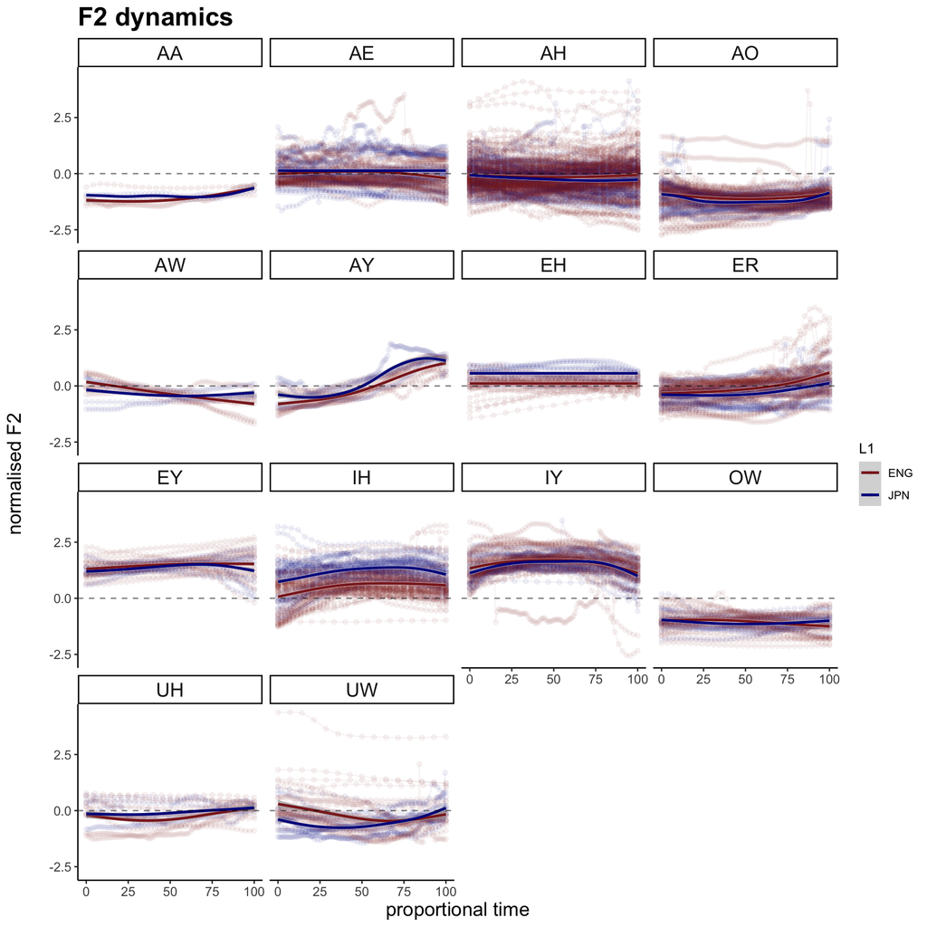

```r
df |>
  dplyr::filter(
    L1 %in% c("ENG", "JPN") # change for different L1 pairs
    ) |>
  ggplot(aes(x = percent, y = f2z, colour = L1)) +
  geom_point(alpha = 0.05) +
  geom_path(aes(group = file), alpha = 0.05) +
  geom_smooth(aes(group = L1), colour = "white", linewidth = 1.2) +
  geom_smooth(aes(group = L1)) + # you could also add smooths
  geom_hline(yintercept = 0, linetype = "dashed", alpha = 0.5) +
  labs(x = "proportional time", y = "normalised F2\n", title = "F2 dynamics") +
  facet_wrap( ~ vowel) +
  scale_colour_manual(values = alpha(c("brown4", "blue4"))) +
  theme(axis.text = element_text(size = 10),
        axis.title = element_text(size = 15),
        strip.text.x = element_text(size = 15),
        strip.text.y = element_text(size = 15, angle = 0),
        plot.title = element_text(size = 20, hjust = 0, face = "bold")
  )
```

# 6 Improving analysis

We’re now familiar with the overall workflow of acoustic analysis using FastTrack. Hooray! FastTrack is very efficient in analysing a large number of vowel tokens. In the data set above, we had a total of 3,071 tokens with the breakdown shown below:

```r
# total number of tokens
df |>
  dplyr::group_by(file, L1) |>
  dplyr::filter(
    percent == "0" # to make sure we only count one data point per file
  ) |>
  dplyr::ungroup() |>
  dplyr::count()
```

```
## # A tibble: 1 × 1
##       n
##   <int>
## 1  3071
```

```r
# by L1
df |>
  dplyr::group_by(file, L1) |>
  dplyr::filter(
    percent == "0" # to make sure we only count one data point per file
  ) |>
  dplyr::ungroup() |>
  dplyr::group_by(L1) |>
  dplyr::count() |>
  dplyr::ungroup()
```

```
## # A tibble: 6 × 2
##   L1        n
##   <chr> <int>
## 1 CCT     563
## 2 CMN     563
## 3 ENG     546
## 4 JPN     282
## 5 KOR     558
## 6 SPA     559
```

However, it is also quite obvious that FastTrack is not free from errors. This is especially important for dynamic analysis, as we’ve found that there are some potential measurement errors.

## 6.1 Manually correcting measurement errors

FastTrack has a few ways to address tracking errors. First, it is possible to manually correct the formant tracking on Praat (but via FastTrack). I have personally never done this, but you can find more information about this [here](https://github.com/santiagobarreda/FastTrack/wiki/Editing-tracks)

## 6.2 Nominating different winners

An alternative approach, which I usually do, is to check the tracking accuracy of the rest of the analyses and see whether there is any ‘better’ analysis. Among the output files, we briefly talked about the **images_comparison** folder, where visualisations are stored for all 24 (or any other specified number of) analysis steps. In my experience (English /l/ and /r/), it is often the case that formant tracking was inaccurate when F3 is extremely low for /r/ and F2/F3 is high for a very clear /l/. Just eyeballing all the comparison images will help you evaluate the formant tracking accuracy fairly quickly (especially when you’re a Mac user where you can just preview all the image files by pressing the space bar.)

When you would like to nominate a different analysis as a winner, you can tell FastTrack to return the tracking results for the particular analysis. This can be done by modifying the **winners.csv** – all you need to do is to simply type in and indicate which analysis is better. You can replace the tracking for all formants at once, or change the tracking of just one formant. Either way, don’t forget to change the number in the **Edit** column from **0** to **1**.

Once you have nominated a different winner by yourself, you need to run **Track folder** again. But this time, untick the **Track formants** and **Autoselect winners** boxes at the bottom, as you’re simply telling FastTrack to use different analysis instead of tracking formants all over again.